# Análisis

Fecha de relevamiento: 29/09/2023 - 11/10/2023

Muchos ecopuntos recolecatban sólo material plástico, por ejemplo botellas. No los usaba la gente en general, si no las personas encargadas del lugar

```
Total de ecopuntos relevados:  22
```

# Estado actual de los ecopuntos

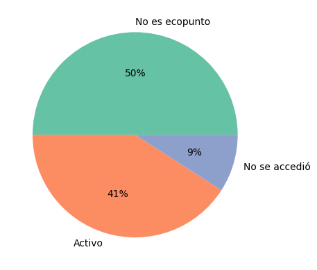

Make this Notebook Trusted to load map: File -> Trust Notebook

[interactive chart not shown]

¿Qué onda YPF PETRO OESTE??

**Interacción**  
Acercar por si no se ven los ecopuntos. Hacer click en la burbuja para ver el estado actual del ecopunto, y en el coso azul para ver el nombre del ecopunto.

**Código de colores:**  
Verde: Activos  
Rojos: No es ecopunto  
Naranja: No se accedió (no se pudo ver ningún ecopunto)

En el mapa podemos ver que los ecopuntos activos se encuentran en su mayor parte en la zona norte de la ciudad de Neuquén.

De los que no se accedieron, el tribunal de faltas se encontraba cerrado a la hora que fuimos (entre las 17 y 18 horas) al igual que la Comisión vecinal Barrio Huiliches. En ningún caso se pudo encontrar un ecopunto visible.

Accesibilidad

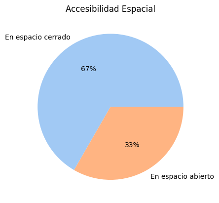

De los 9 ecopuntos que se encontraban activos, el 67% se encontraba en un espacio cerrado, es decir, había algún elemento de por medio que impedía el libre acceso: dentro de algún edificio, cercados con algún portón.

El caso más extremo fue sin duda el de ALTO COMAHUE SHOPPING que se encontraba en el subsuelo donde se encuentra el estacionamiento, escondido atrás de una pared. Tuvimos que preguntar al menos a dos guardias en distintos puntos del shopping para saber dónde se ubicaba el ecopunto.

Por otro lado, muchos de ellos eran utilizados en su mayoría por personas que atendían el lugar. Y sólo funcionaba cuando ese lugar se encontraba abierto o habían eventos deportivos.

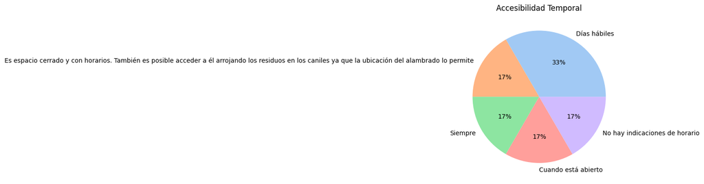

Con respecto a la accesibilidad temporal de los ecopuntos que se encuentran en espacio cerrado, muchos se encuentran con horarios. Es decir que no están disponibles todo el tiempo. Y el que dice Siempre es el ALTO COMAHUE SHOPPING, que a pesar de estar siempre abierto, se encuentra inaccesible.

Además, algunos no tenían indicaciones de horarios ni siquiera.

**Determinando la accesibilidad**

Si tomamos en cuenta los casos donde los ecopuntos se encuentran en espacio cerrado y hay horarios, y adicionamos el caso más extremo en cuanto a accesibilidad espacial, obtenemos el siguiente gráfico en cuanto a accesibilidad general de los ecopuntos que se encuentran activos y que se pudieorn acceder y visualizar.

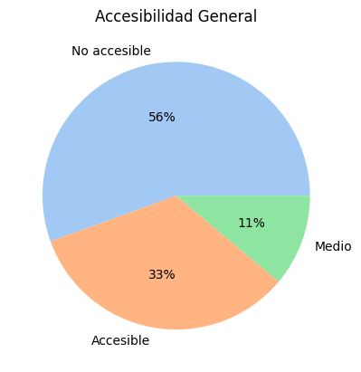

Make this Notebook Trusted to load map: File -> Trust Notebook

[interactive chart not shown]

**Verde**: Accesible  
**Rojo**: Accesibilidad media  
Naranja: no accesible

En el mapa podemos ver que de los ecopuntos activos, sólo tres son totalmente accesibles, y se encuentran en la zona norte-oeste de la ciudad de Neuquén.

¿Queremos un sistema de reciclaje en el que la recolección de residuos sea accesible? ¿Estamos dispuestos a ser responsables? ¿Disponemos de un sistema que se encargue de la recolección eficiente? ¿A dónde se destinan estos residuos? ¿Qué es lo que se hace luego? ¿Vale la pena nuestro esfuerzo hoy en día?

# Estado de los ecopuntos

Sería qué tan bien cuidado se encontraban los ecopuntos

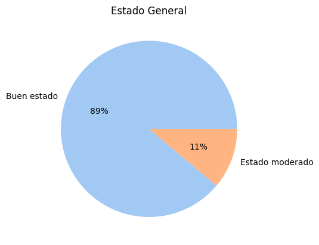

Están bastante bien

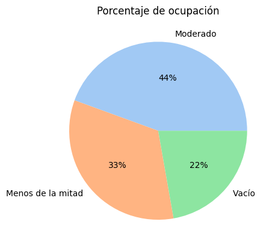

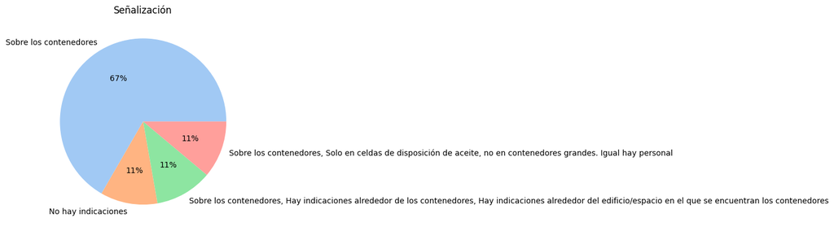

Hay alguna relación entre la señalización y la ocupación de los contenedores? y entre la señalización y la accesibilidad espacial?

**Grado de ocupación vs señalización**

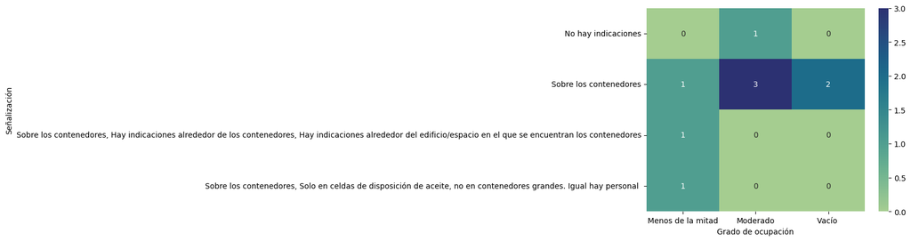

**Accesibilidad espacial vs señalización**

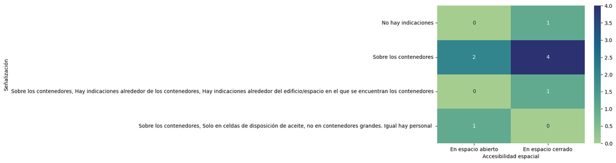

Vemos que 4 ecopuntos se encuentran en espacio cerrado y sólo tienen señalización sobre los contenedores, es señalización suficiente???

# Ubicación

Distancia en kilómetros

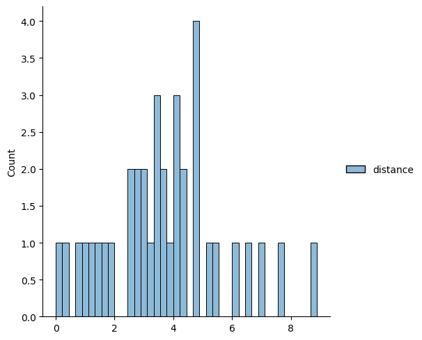

El promedio de distancias es entre 3 y 6 kilómetros

## Análisis en función de las zonas de la ciudad. Identificación de conglomerados de ecopuntos.

```
<folium.vector_layers.PolyLine at 0x7bb65aed6da0>
```

Make this Notebook Trusted to load map: File -> Trust Notebook

[interactive chart not shown]

```
((7, 21), (1, 21), (1, 21), (0, 21))
```

Si establecemos que hasta 500 metros una persona podría acercarse al ecopunto caminando..

```
<folium.vector_layers.PolyLine at 0x7bb65b84fb50>
```

Make this Notebook Trusted to load map: File -> Trust Notebook

[interactive chart not shown]

Algunos ecopuntos se solapan, otros no llegan a cubrir la totalidad de la región. Los ciudadanos deben trasladarse en automóvil para acercarse al ecopunto.

[output not shown]